# The association of public safety power shutoffs (PSPS) events with hospital visits

26 April, 2025

## Public safety power shutoffs (PSPS) events: research motivation

**Research motivation**:

- Wildfires have been increasing in frequency and intensity
- Wildfire smoke is associated with adverse health outcomes
- One cause of wildfires are power lines
- Power outages are associated with adverse health outcomes

An important **mitigation strategy** for higher wildfire risk rolled out in California and increasingly adopted in other states is **public safety power shutoffs (PSPS)**, which are planned power outages to prevent power lines from causing fires.

However, PSPS events are implemented during times of high wildfire risk, and are thus likely to co-occur with the very thing they are trying to prevent: wildfire smoke.

## Public safety power shutoffs (PSPS) events: research questions

- **What are the effects of PSPS events on adverse health outcomes?**
- **What is the extent of dual wildfire smoke-PSPS exposure?**
- **What is the association between this dual exposure and adverse health outcomes?**

## Background

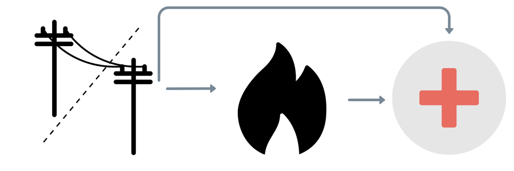

## Methods

| Type | Data | Coverage | Years |
| --- | --- | --- | --- |
| Exposure | Public safety power shutoff (PSPS) data, PSE | Event, circuit-level data from the three major utility providers in CA (PGE, SDG&E, SCE) | 2013-2022 |
| Exposure | Wildfire PM<sub>2.5</sub> data, Aguilera et al. 2023 Environ Int | Daily, zip code-level | 2006 – 2020 |
| Outcome | Hospital and emergency department data, California Department of Health Care Access and Information (HCAI) | Daily, zip-code level visits | 2013-2019 |

- **Study population**: Adults (18+) in California
- **Study period**: 2013-2019
- **Study design**: Time-stratified case-crossover design
- **Statistical analysis**: Conditional logistic regression

## Exposure distribution

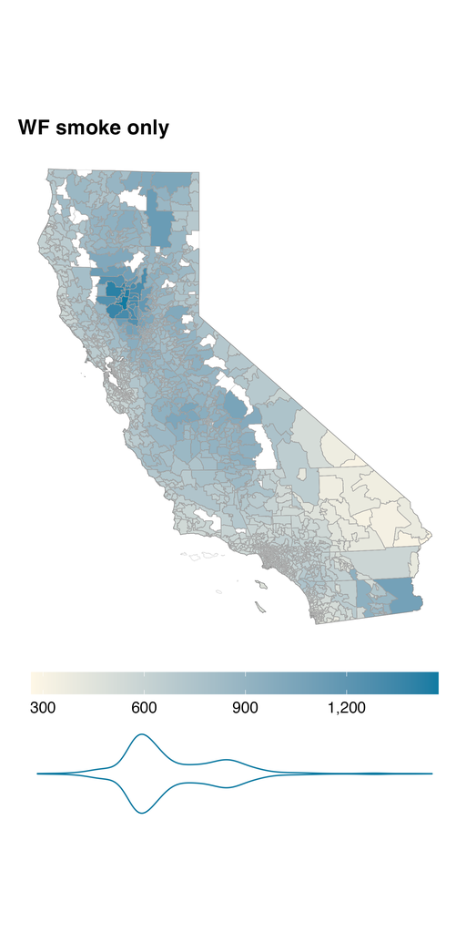

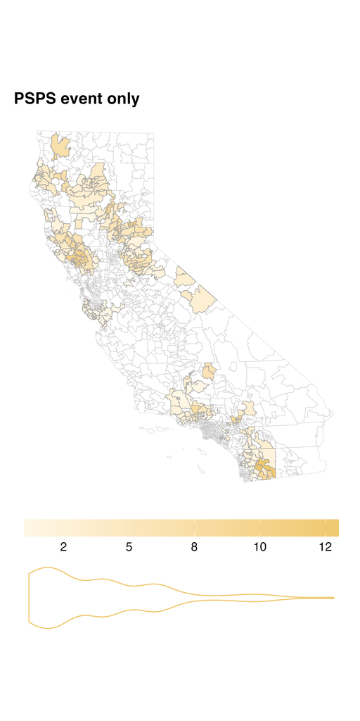

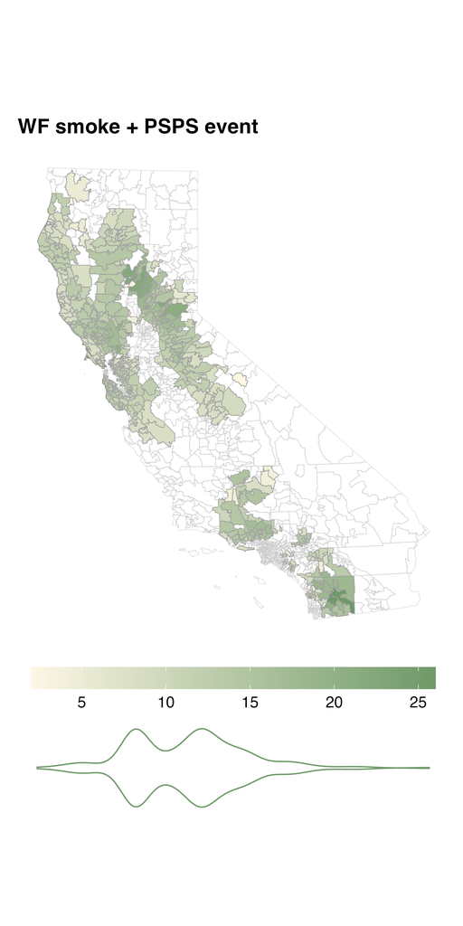

Geographic distribution of days of exposure in California, 2013-2019.

## Results: absolute number of customers impacted

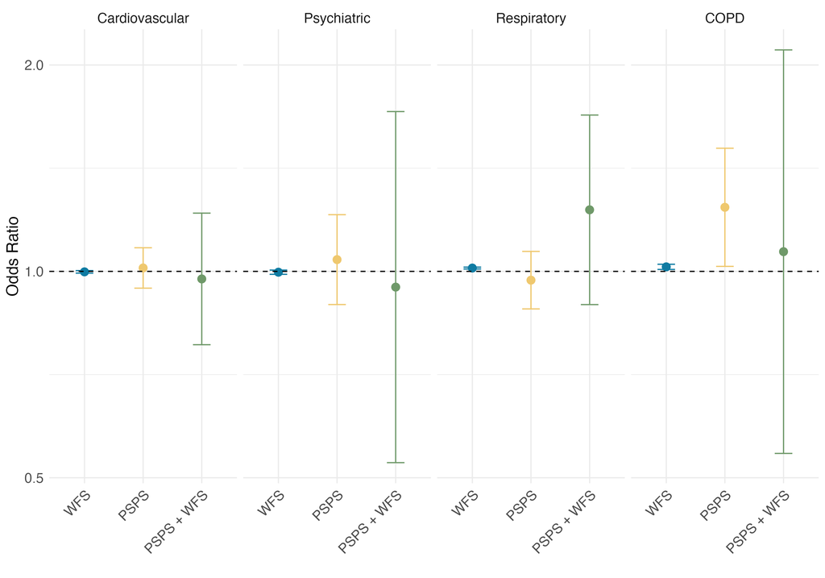

## Thank you!

wilnerl@uw.edu